# Home

# Dr. Florian Pethig

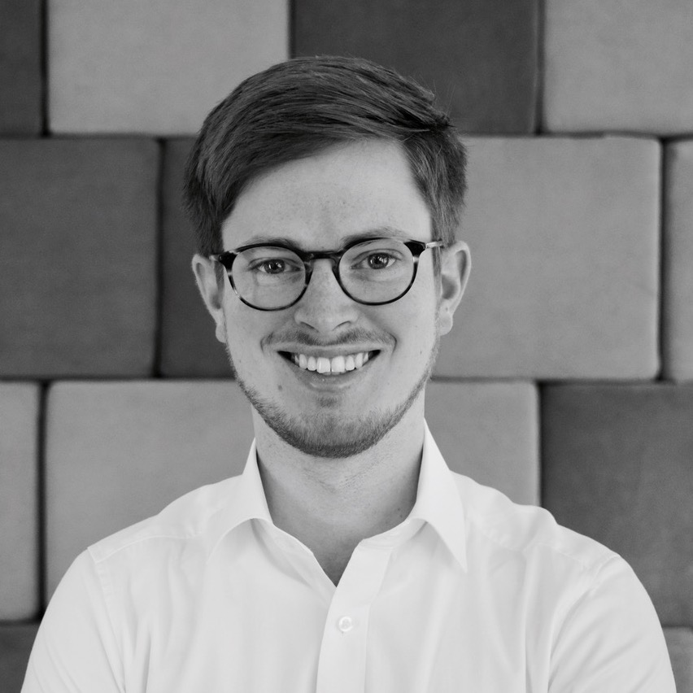

I am an assistant professor (non-tenure track, *akademischer Rat a.Z.*) in information systems at [University of Mannheim](https://www.bwl.uni-mannheim.de/hoehle/team/wissenschaftliche-mitarbeiter/florian-pethig/). I received my M.Sc. and PhD in information systems from the University of Mannheim. I previously worked as a business data analyst at [zeroG](https://www.zerog.aero) (Lufthansa Group), specializing in data science and the digital transformation. I study the societal impact of technology and user behavior on digital platforms. My work has appeared in Journal of the Association for Information Systems, Journal of Business Ethics, and Government Information Quarterly.

You can email me at: pethig@uni-mannheim.de

## Journal Publications

Pethig F, Kroenung J (2023). “[Biased humans, (un) biased algorithms?](https://link.springer.com/content/pdf/10.1007/s10551-022-05071-8.pdf).” *Journal of Business Ethics*, *183*, 637-652.

- Replication code and data on [OSF](https://osf.io/axgp2/).
- Media:
  - “Will Algorithms Remove Gender Bias in Hiring?” [Psychology Today](https://www.psychologytoday.com/us/blog/the-behavioral-science-hub/202210/will-algorithms-remove-gender-bias-in-hiring).
  - “Algorithme, leadership : vers une parité Homme/Femme,” [Forbes France](https://www.forbes.fr/business/algorithme-leadership-vers-une-parite-homme-femme/).

Pethig F, Kroenung J, Noeltner M (2021). “[A stigma power perspective on digital government service avoidance](https://www.sciencedirect.com/science/article/pii/S0740624X20303245).” *Government Information Quarterly*, *38*(2), 101545.

Pethig F, Kroenung J (2019). “[Specialized information systems for the digitally disadvantaged](https://aisel.aisnet.org/jais/vol20/iss10/5/).” *Journal of the Association for Information Systems*, *20*(10), 247-265.

## Working Paper

Pethig F, Hoehle H, Hui KL, Lanz A (2022). “Behavior toward newcomers and contributions to online communities.” *Working paper*.